# inovick_finalhomeworkcode_02

### Every Saturday morning, at the same time, a primatologist goes and sits in the forest to listen for titi monkey calls, counting the number of calls they hear in a 2 hour window from 5am to 7am. Based on previous knowledge, she believes that the mean number of calls she will hear in that time is exactly 15. Let X represent the appropriate Poisson random variable of the number of calls heard in each monitoring session.

## Challenge 1: What is the probability that she will hear more than 8 calls during any given session?

```r
?dpois #to give me more information on the Poisson Distribution

x<-8
l<-15
1-ppois(q=x,lambda=l)
```

```
## [1] 0.9625535
```

```r
#Probability=0.9625535 or 96%
```

## Challenge 2: What is the probability that she will hear no calls in a session?

```r
dpois(0,15)
```

```
## [1] 3.059023e-07
```

```r
#Probability=3.059023e-07
```

## Challenge 3: What is the probability that she will hear exactly 3 calls in a session?

```r
dpois(3,15)
```

```
## [1] 0.0001720701
```

```r
#Probability=0.0001720701
```

## Challenge 4: Plot the relevant Poisson mass function over the values in range 0 ≤ x ≤ 30

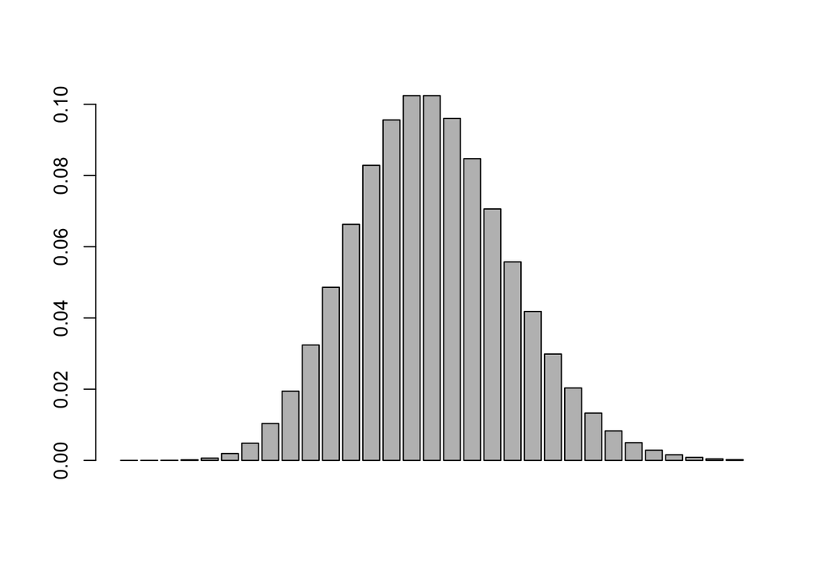

```r
x<-0:30
l=15
barplot(dpois(x,l))
```

## Challenge 5: Simulate 104 results from this distribution (i.e., 2 years of Saturday monitoring sessions).

```r
rpois(104,15) #simulated 104 results from this distribution
```

```
##   [1] 14 17 23 15 17 20 12 21  9 14 17 16 12 12 11  8 14 14 13 15 15 13 14 11  7
##  [26] 17 14 15 16 21 12 20 20 24 15 12 18 13  9 15 17 10 12 20 15 25 12 13 14 11
##  [51] 22 12 12 18 20 19 10 10 13 19 11 11 16 16 15 10 14 15 15 19 16 16 13 13 12
##  [76] 16 11 16 14 17 15 11 23 15 16 18 12 16 16 14 10 14 16 18 11 14 10 10 14 17
## [101] 23 18 16 21
```

## Challenge 6: Plot the simulated results using hist() and use xlim() to set the horizontal limits to be from 0 to 30. How does your histogram compare to the shape of the probability mass function you plotted above?

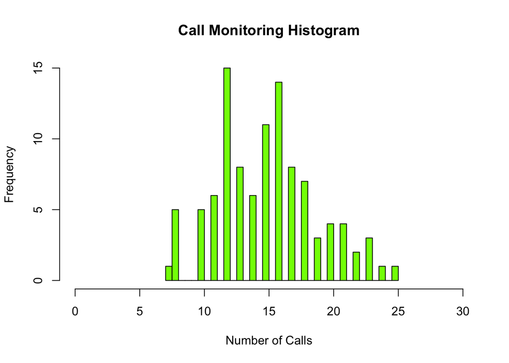

```r
y<-rpois(104,15)
hist(y,xlim=c(0,30),xlab="Number of Calls",main="Call Monitoring Histogram",breaks=30,col="chartreuse")
```